# Model Selection and Model Checking (in Poisson Regression, and GLMs)

We shall study the basics of model selection and model checking for Poisson regression in the context of the Mroz dataset from last lecture (this dataset has data on a bunch of economic variables for married women in the year 1975). We shall then take a unified look at linear regression, logistic regression and Poisson regression as special cases of a general class of models called Generalized Linear Models.

```python
import pandas as pd
import numpy as np
import statsmodels.api as sm
```

```python
#Import the MROZ.csv dataset
mroz = pd.read_csv("MROZ.csv")
print(mroz.head(12))
```

```
    inlf  hours  kidslt6  kidsge6  age  educ    wage  repwage  hushrs  husage  \
0      1   1610        1        0   32    12  3.3540     2.65    2708      34
1      1   1656        0        2   30    12  1.3889     2.65    2310      30
2      1   1980        1        3   35    12  4.5455     4.04    3072      40
3      1    456        0        3   34    12  1.0965     3.25    1920      53
4      1   1568        1        2   31    14  4.5918     3.60    2000      32
5      1   2032        0        0   54    12  4.7421     4.70    1040      57
6      1   1440        0        2   37    16  8.3333     5.95    2670      37
7      1   1020        0        0   54    12  7.8431     9.98    4120      53
8      1   1458        0        2   48    12  2.1262     0.00    1995      52
9      1   1600        0        2   39    12  4.6875     4.15    2100      43
10     1   1969        0        1   33    12  4.0630     4.30    2450      34
11     1   1960        0        1   42    11  4.5918     4.58    2375      47

    ...  faminc     mtr  motheduc  fatheduc  unem  city  exper   nwifeinc  \
```

[output cut: 28 more lines]

In the last lecture, we fit the following Poisson regression model for the response "hours" in terms of the covariates "kidslt6", "age", "educ", "huswage", "exper" and "expersq".

```python
#Poisson Regression through StatsModels
# Define the response variable and covariates
Y = mroz['hours']
X = mroz[['kidslt6', 'age', 'educ',
        'huswage', 'exper', 'expersq']].copy()
X = sm.add_constant(X) # Add a constant (intercept) to the model
# Fit the Poisson regression model
poiregmodel = sm.GLM(Y, X, family=sm.families.Poisson()).fit()
print(poiregmodel.summary())
```

```
                 Generalized Linear Model Regression Results
==============================================================================
Dep. Variable:                  hours   No. Observations:                  753
Model:                            GLM   Df Residuals:                      746
Model Family:                 Poisson   Df Model:                            6
Link Function:                    Log   Scale:                          1.0000
Method:                          IRLS   Log-Likelihood:            -3.1563e+05
Date:                Thu, 05 Oct 2023   Deviance:                   6.2754e+05
Time:                        05:51:51   Pearson chi2:                 6.60e+05
No. Iterations:                     5   Pseudo R-squ. (CS):              1.000
Covariance Type:            nonrobust
==============================================================================
                 coef    std err          z      P>|z|      [0.025      0.975]
------------------------------------------------------------------------------
const          6.9365      0.012    562.281      0.000       6.912       6.961
kidslt6       -0.8075      0.004   -193.217      0.000      -0.816      -0.799
age           -0.0427      0.000   -201.166      0.000      -0.043      -0.042
educ           0.0528      0.001     83.439      0.000       0.052       0.054
huswage       -0.0207      0.000    -54.548      0.000      -0.021      -0.020
exper          0.1204      0.001    219.231      0.000       0.119       0.121
expersq       -0.0018   1.63e-05   -112.090      0.000      -0.002      -0.002
==============================================================================
```

We have seen in the last class that "kidslt6" is an important variable and its coefficient -0.8075 for the "kidslt6" variable gives the following interpretation: having a small kid reduces mean hours worked by 55% (holding all other variables fixed). This 55% comes from the following calculation:

```python
#55% comes from:
print((np.exp(poiregmodel.params['kidslt6']) - 1)*100)
```

```
-55.40391074218227
```

55% is a significant reduction. For a concrete example, consider a woman with kidslt6 = 0, age = 30, educ = 16, huswage = 10, exper = 10, expersq = 100. The prediction for "Hours" for the above Poisson regression model is given by 1502 as given by the code below.

```python
coef = poiregmodel.params.values
kidslt6 = 0
age = 30
educ = 16
huswage = 10
exper = 10
expersq = 100
pred = np.exp(coef[0] + coef[1]*kidslt6 + coef[2]*age + coef[3]*educ + coef[4]*huswage + coef[5]*exper + coef[6]*expersq)
print(pred)
```

```
1502.8004946558758
```

Now suppose we change kidslt6 = 1. Then the hours predicted would decrease by 55% which means that the prediction would be more than halved as can be verified as follows.

```python
coef = poiregmodel.params.values
kidslt6 = 1
age = 30
educ = 16
huswage = 10
exper = 10
expersq = 100
pred = np.exp(coef[0] + coef[1]*kidslt6 + coef[2]*age + coef[3]*educ + coef[4]*huswage + coef[5]*exper + coef[6]*expersq)
print(pred)
```

```
670.1902499636603
```

Now suppose kidslt6 = 2, then the hours predicted would be further decreased by 55% leading to:

```python
coef = poiregmodel.params.values
kidslt6 = 2
age = 30
educ = 16
huswage = 10
exper = 10
expersq = 100
pred = np.exp(coef[0] + coef[1]*kidslt6 + coef[2]*age + coef[3]*educ + coef[4]*huswage + coef[5]*exper + coef[6]*expersq)
print(pred)
```

```
298.8786420709859
```

Thus compared to kidslt6 = 0 for which the prediction was 1500 hours, the prediction of hours for kidslt6 = 2 (with all other variables remaining the same) is only 300 hours which is a huge reduction. This speaks to the importance of the variable 'kidslt6' in this model. Other important variables in this model are 'age' and 'exper'. One way to gauge the importance of a variable in a regression model is to look at the absolute value of its corresponding regression coefficient. However, different variables (and different coefficients) have different units so the value is hard to interpret. A standard unit-free measure of the importance of a variable in regression is the ratio of the estimated coefficient to the standard error. If this ratio is large in absolute value, then the variable is considered important. In the regression summary table, this ratio is given in the column titled "z" (for linear regression, this column would be titled "t"). By this yardstick, the three most important variables in this regression are 'exper', 'age' and 'kidslt6'.

The regression coefficient for 'age' can be interpreted as follows. If 'age' increases by one (and all other variables are held fixed), then expected hours decreases by a factor of $\exp(-0.0427) \approx 0.96$ or equivalently, by 4 percent. If 'age' increases by ten (and all other variables are held fixed), then expected hours decreases by a factor of $\exp(-0.427) \approx 0.65$, or equivalently, by $35$ percent.

The regression coefficient for 'exper' is a little more complicated to interpret because of the presence of 'expersq = $\text{exper}^2$'. The presence of 'expersq' makes it impossible to change 'exper' while keeping the other variables fixed. The two coefficients of 'exper' and 'expersq' can be combined to obtain an interpretation of the change in 'hours' with respect to 'exper' while keeping 'age', 'kidslt6', 'educ', 'huswage' fixed.

## Model Selection

Suppose we replace "kidslt6" by "kidsge6" and refit the model. We would expect this to result in a model that is much worse than the above model. How would be confirm that the resulting model would be indeed worse? This is a problem of **model selection** where we have to compare between two models.

The following code fits the new model where we replace "kidslt6" by "kidsge6".

```python
Y = mroz['hours']
X1 = mroz[['kidsge6', 'age', 'educ',
        'huswage', 'exper', 'expersq']].copy() #'kidslt6' is now replaced by 'kidsge6'
X1 = sm.add_constant(X1)
poiregmodel1 = sm.GLM(Y, X1, family=sm.families.Poisson()).fit()
print(poiregmodel1.summary())
```

```
                 Generalized Linear Model Regression Results
==============================================================================
Dep. Variable:                  hours   No. Observations:                  753
Model:                            GLM   Df Residuals:                      746
Model Family:                 Poisson   Df Model:                            6
Link Function:                    Log   Scale:                          1.0000
Method:                          IRLS   Log-Likelihood:            -3.4027e+05
Date:                Thu, 05 Oct 2023   Deviance:                   6.7681e+05
Time:                        05:52:25   Pearson chi2:                 6.78e+05
No. Iterations:                     5   Pseudo R-squ. (CS):              1.000
Covariance Type:            nonrobust
==============================================================================
                 coef    std err          z      P>|z|      [0.025      0.975]
------------------------------------------------------------------------------
const          6.2418      0.013    485.960      0.000       6.217       6.267
kidsge6       -0.0084      0.001     -7.347      0.000      -0.011      -0.006
age           -0.0278      0.000   -135.231      0.000      -0.028      -0.027
educ           0.0410      0.001     65.183      0.000       0.040       0.042
huswage       -0.0214      0.000    -56.022      0.000      -0.022      -0.021
exper          0.1348      0.001    245.305      0.000       0.134       0.136
expersq       -0.0022   1.62e-05   -136.487      0.000      -0.002      -0.002
==============================================================================
```

Comparing the regression outputs of these two models, how do we tell which model is better? This question is answered using some **model selection criteria**. The simplest model selection criteria are **log-likelihood** and **deviance**. These quantities are provided in the outputted summary of each model and can be obtained by the following code.

```python
#Log-likelihoods for the two models:
logLik_model = poiregmodel.llf
logLik_model1 = poiregmodel1.llf

#Deviances for the two models:
deviance_model = poiregmodel.deviance
deviance_model1 = poiregmodel1.deviance

# Print results
print(f"Model with 'kidslt6': Log-Likelihood = {logLik_model}, Deviance = {deviance_model}")
print(f"Model with 'kidsge6': Log-Likelihood = {logLik_model1}, Deviance = {deviance_model1}")
```

```
Model with 'kidslt6': Log-Likelihood = -315632.12091262755, Deviance = 627538.4070785991
Model with 'kidsge6': Log-Likelihood = -340265.97607505764, Deviance = 676806.1174034592
```

### More details for log-likelihood and deviance

The log-likelihood for a model is simply the maximum possible value of the log-likelihood for that model (equivalently, it is the log-likelihood evaluated at the MLE). The deviance for a model is defined as: \begin{align*} \text{deviance} = (-2) \times \text{maximized log-likelihood} + \text{constant} \end{align*} where the "constant" depends on the dataset but not the specific model under consideration (for example, this constant term will be identical for the two Poisson regression models with 'kidslt6' and 'kidsge6').

When comparing models using log-likelihood, we prefer models with larger log-likelihood. When comparing models using deviance, we prefer models with smaller deviance. For example, the log-likelihood for the model with 'kidslt6' is higher compared to the model with 'kidsge6', so we would prefer the model with 'kidslt6'. Equivalently, the deviance for the model with 'kidslt6' is lower compared to the model with 'kidsge6' so we again prefer the model with 'kidslt6'. Note that using log-likelihood or deviance should lead to identical results because of their mathematical relationship.

### AIC and BIC

Using log-likelihood (or deviance) to compare models $M_1$ and $M_2$ works well when both have a similar number of parameters. However if $M_1$ has many more parameters compared to $M_2$, then the maximized log-likelihood for $M_1$ could be larger than that of $M_2$ not because $M_1$ is learning some important structure in the data, but just because $M_1$ is overfitting to the training dataset. To rectify this, one usually modifies the log-likelihood by adding a **penalty** term which penalizes models with more paramters. AIC (Akaike Information Criterion) and BIC (Bayesian Information Criterion) are two such penalized likelihood criteria. Their definitions are as follows: \begin{align*} & \text{AIC}(\text{model}) = (-2) \times \text{log-likelihood}(\text{model}) + 2 \times \text{number of parameters in model} \\ & \text{BIC}(\text{model}) = (-2) \times \text{log-likelihood}(\text{model}) + (\log n) \times \text{number of parameters in model}, \end{align*} where, in the formula for BIC, $n$ stands for the number of observations in the dataset. For example, the MROZ dataset gives data for 753 women so $n = 753$. When using the AIC or BIC for model selection, we prefer models with smaller values.

```python
#AIC and BIC for the two models (with 'kidslt6' and 'kidsge6')
aic_model = poiregmodel.aic
aic_model1 = poiregmodel1.aic

bic_model = poiregmodel.bic_llf
bic_model1 = poiregmodel1.bic_llf

print(f"Model with 'kidslt6': AIC = {aic_model}, BIC = {bic_model}")
print(f"Model with 'kidsge6': AIC = {aic_model1}, BIC = {bic_model1}")

#Instead of using .aic and .bic, we can calculate these using llf and the formula as follows:
num_params = 7
#the number of parameters equals 7 in both these models. The 7 parameters are beta_0, beta_1, beta_2,
#beta_3, beta_4, beta_5, beta_6
aic_model_formula = (-2)*poiregmodel.llf + 2*7
aic_model1_formula = (-2)*poiregmodel1.llf + 2*7

n = mroz.shape[0]
bic_model_formula = (-2)*poiregmodel.llf + np.log(n) * 7
bic_model1_formula = (-2)*poiregmodel1.llf + np.log(n) * 7

print(f"Model with 'kidslt6': AIC = {aic_model_formula}, BIC = {bic_model_formula}")
print(f"Model with 'kidsge6': AIC = {aic_model1_formula}, BIC = {bic_model1_formula}")
```

```
Model with 'kidslt6': AIC = 631278.2418252551, BIC = 631310.6102818497
Model with 'kidsge6': AIC = 680545.9521501153, BIC = 680578.3206067099
Model with 'kidslt6': AIC = 631278.2418252551, BIC = 631310.6102818497
Model with 'kidsge6': AIC = 680545.9521501153, BIC = 680578.3206067099
```

Both models here have the same number of parameters so model selection by AIC and BIC would lead to equivalent results as model selection via log-likelihood or deviance.

In general, it is common practice to throw in a large number of explanatory variables, and then to search through all possible subsets of explanatory variables by looking at their AIC or BIC values. The model with the smallest possible AIC or BIC will then be selected as the 'best model'. Note that AIC and BIC can lead to different best models. Also note that this subset search for the best model will not work if we use log-likelihood or deviance as the model selection criterion simply because the model with the smallest deviance will always be the full model i.e., the model with all the variables.

Here is an illustration of model selection in this Poisson regression example. First let us consider the following regression model which includes 13 explanatory variables: 'kidslt6', 'kidsge6', 'age', 'educ', 'hushrs', 'huseduc', 'huswage', 'motheduc', 'fatheduc', 'exper', 'expersq', 'unem', 'city'. The "full" model will use all these variables to predict 'hours'. Here is the output for the full model:

```python
Y = mroz['hours']
Xfull = mroz[['kidslt6', 'kidsge6', 'age', 'educ', 'hushrs', 'huseduc', 'huswage',
           'motheduc', 'fatheduc', 'exper', 'expersq', 'unem', 'city']]
Xfull = sm.add_constant(Xfull)
poiregmodel_full = sm.GLM(Y, Xfull, family=sm.families.Poisson()).fit()
print(poiregmodel_full.summary())
```

```
                 Generalized Linear Model Regression Results
==============================================================================
Dep. Variable:                  hours   No. Observations:                  753
Model:                            GLM   Df Residuals:                      739
Model Family:                 Poisson   Df Model:                           13
Link Function:                    Log   Scale:                          1.0000
Method:                          IRLS   Log-Likelihood:            -3.1222e+05
Date:                Thu, 05 Oct 2023   Deviance:                   6.2072e+05
Time:                        05:52:37   Pearson chi2:                 6.53e+05
No. Iterations:                     5   Pseudo R-squ. (CS):              1.000
Covariance Type:            nonrobust
==============================================================================
                 coef    std err          z      P>|z|      [0.025      0.975]
------------------------------------------------------------------------------
const          7.4625      0.015    503.407      0.000       7.433       7.492
kidslt6       -0.8180      0.004   -194.435      0.000      -0.826      -0.810
kidsge6       -0.0369      0.001    -31.452      0.000      -0.039      -0.035
age           -0.0433      0.000   -194.433      0.000      -0.044      -0.043
educ           0.0604      0.001     74.681      0.000       0.059       0.062
hushrs        -0.0001    2.5e-06    -49.100      0.000      -0.000      -0.000
huseduc       -0.0135      0.001    -22.282      0.000      -0.015      -0.012
huswage       -0.0241      0.000    -55.083      0.000      -0.025      -0.023
motheduc       0.0137      0.000     27.570      0.000       0.013       0.015
fatheduc      -0.0037      0.000     -7.535      0.000      -0.005      -0.003
exper          0.1177      0.001    212.420      0.000       0.117       0.119
expersq       -0.0018   1.64e-05   -112.054      0.000      -0.002      -0.002
unem          -0.0195      0.000    -42.213      0.000      -0.020      -0.019
city           0.0452      0.003     14.890      0.000       0.039       0.051
==============================================================================
```

Next we implement "best subsets" Poisson regression where we search over all possible submodels of the full model to find the model with the smallest AIC. In order to search over all subsets, we need some way of enumerating all substes of the 13 variables. For this, the following Python function will be useful. This function returns a list of all possible subsets of size $k$ from a given 'arr'. For example, if arr equals ['a', 'b', 'c', 'd', 'e'] and $k = 3$, this should give the output: ['e', 'd', 'c'], ['e', 'd', 'b'], ['e', 'c', 'b'], ['d', 'c', 'b'], ['e', 'd', 'a'], ['e', 'c', 'a'], ['d', 'c', 'a'], ['e', 'b', 'a'], ['d', 'b', 'a'], ['c', 'b', 'a'].

```python
#All subsets of size k
def get_combinations(arr, k):
    if k == 0:
        return [[]]
    if not arr:
        return []
    return get_combinations(arr[1:], k) + [x + [arr[0]] for x in get_combinations(arr[1:], k-1)]
print(get_combinations(['a', 'b', 'c', 'd', 'e'], 3))
```

```
[['e', 'd', 'c'], ['e', 'd', 'b'], ['e', 'c', 'b'], ['d', 'c', 'b'], ['e', 'd', 'a'], ['e', 'c', 'a'], ['d', 'c', 'a'], ['e', 'b', 'a'], ['d', 'b', 'a'], ['c', 'b', 'a']]
```

Using the above function, for each $k = 1, 2, 3, \dots, 13$, we obtain all possible subsets of size $k$ of the full set consisting of all variables ('kidslt6', 'kidsge6', 'age', 'educ', 'hushrs', 'huseduc', 'huswage', 'motheduc', 'fatheduc', 'exper', 'expersq', 'unem', 'city'), then for each subset of size $k$, we calculate the AIC of the Poisson regression model with that subset. We then select the best subset model for each $k$ and report these best models. Finally, we look at the AICs of the best models for each $k$ and select the best model among these 13 models.

```python
#Best Subsets Poisson Regression using AIC
Y = mroz['hours']
Xfull = mroz[['kidslt6', 'kidsge6', 'age', 'educ', 'hushrs', 'huseduc', 'huswage',
           'motheduc', 'fatheduc', 'exper', 'expersq', 'unem', 'city']]

best_aic_per_k = {}

# Looping through all possible sizes of predictor subsets
for k in range(1, len(Xfull.columns) + 1):

    # Getting all combinations of predictors of size k without using itertools
    best_aic_k = float("inf")
    best_model_k = None
    best_variables_k = None

    for variables in get_combinations(list(Xfull.columns), k):
        predictors = Xfull[list(variables)]
        predictors = sm.add_constant(predictors)  # Add a constant (intercept) to the model

        # Fitting the model
        model = sm.GLM(Y, predictors, family=sm.families.Poisson()).fit()

        # Updating best AIC model for each k
        if model.aic < best_aic_k:
            best_aic_k = model.aic
            best_model_k = model
            best_variables_k = variables  # Storing variable names

    # Storing the best AIC and variable names for each k in the dictionary
    best_aic_per_k[k] = (best_aic_k, best_model_k, best_variables_k)

# Displaying the results
for k, (aic, model, variables) in best_aic_per_k.items():
    print(f"\nBest AIC value for k={k} variables: {aic}")
    print(f"Variables in the model: {variables}")
    print(f"Model parameters:\n{model.params}")
```

```
Best AIC value for k=1 variables: 744498.6174901996
Variables in the model: ['exper']
Model parameters:
const    5.997464
exper    0.049036
dtype: float64

Best AIC value for k=2 variables: 708125.6250492265
Variables in the model: ['exper', 'age']
Model parameters:
const    7.340090
exper    0.066197
age     -0.036907
dtype: float64

Best AIC value for k=3 variables: 653555.3560647196
Variables in the model: ['exper', 'age', 'kidslt6']
Model parameters:
const      8.134844
exper      0.064158
age       -0.051846
kidslt6   -0.846538
dtype: float64

Best AIC value for k=4 variables: 639269.8868831303
Variables in the model: ['expersq', 'exper', 'age', 'kidslt6']
Model parameters:
const      7.513553
expersq   -0.001812
exper      0.122583
age       -0.045117
kidslt6   -0.793601
dtype: float64

Best AIC value for k=5 variables: 634410.2632771938
Variables in the model: ['expersq', 'exper', 'educ', 'age', 'kidslt6']
Model parameters:
const      6.970329
expersq   -0.001774
exper      0.120684
```

[output cut: 113 more lines]

```
const       7.462458
city        0.045172
unem       -0.019463
expersq    -0.001838
exper       0.117729
fatheduc   -0.003659
motheduc    0.013728
huswage    -0.024136
huseduc    -0.013512
hushrs     -0.000123
educ        0.060386
age        -0.043270
kidsge6    -0.036885
kidslt6    -0.818034
dtype: float64
```

The above output shows that the best model with one explanatory variable ($k = 1$) is the model for 'hours' in terms of 'exper' (in other words, the most important variable for explaning hours is exper). The best model with two explanatory variables ($k = 2$) is the model for 'hours' in terms of 'exper' and 'age'. The best model with three explanatory variables ($k = 3$) is the model for 'hours' in terms of 'exper','age' and 'kidslt6', and so on. If we want the overall best model regardless of $k$, then we will have to look at the AIC values among the best models for each $k$. In this example, the best overall model in terms of AIC is the full model with all 13 variables. In other datasets, the best overall model might be smaller than the full model.

The same analysis can be redone with the BIC (instead of the AIC). The code for this is as follows.

```python
#Best subsets regression with BIC.

import statsmodels.genmod.generalized_linear_model as glm
glm.SET_USE_BIC_LLF(True) #this silences the warnings for BIC

#Best BIC Model:
best_bic_per_k = {}

# Looping through all possible sizes of predictor subsets
for k in range(1, len(Xfull.columns) + 1):

    best_bic_k = float("inf")
    best_model_k = None
    best_variables_k = None

    for variables in get_combinations(list(Xfull.columns), k):
        predictors = Xfull[list(variables)]
        predictors = sm.add_constant(predictors)  # Add a constant (intercept) to the model

        # Fitting the model
        model = sm.GLM(Y, predictors, family=sm.families.Poisson()).fit()

        # Updating best BIC model for each k
        if model.bic < best_bic_k:  # Using BIC instead of AIC here
            best_bic_k = model.bic  # Updating BIC value
            best_model_k = model
            best_variables_k = variables  # Storing variable names

    # Storing the best BIC and variable names for each k in the dictionary
    best_bic_per_k[k] = (best_bic_k, best_model_k, best_variables_k)

# Displaying the results
for k, (bic, model, variables) in best_bic_per_k.items():
    print(f"\nBest BIC value for k={k} variables: {bic}")
    print(f"Variables in the model: {variables}")
    print(f"Model parameters:\n{model.params}")
```

```
Best BIC value for k=1 variables: 744507.8656206552
Variables in the model: ['exper']
Model parameters:
const    5.997464
exper    0.049036
dtype: float64

Best BIC value for k=2 variables: 708139.4972449099
Variables in the model: ['exper', 'age']
Model parameters:
const    7.340090
exper    0.066197
age     -0.036907
dtype: float64

Best BIC value for k=3 variables: 653573.8523256308
Variables in the model: ['exper', 'age', 'kidslt6']
Model parameters:
const      8.134844
exper      0.064158
age       -0.051846
kidslt6   -0.846538
dtype: float64

Best BIC value for k=4 variables: 639293.0072092693
Variables in the model: ['expersq', 'exper', 'age', 'kidslt6']
Model parameters:
const      7.513553
expersq   -0.001812
exper      0.122583
age       -0.045117
kidslt6   -0.793601
dtype: float64

Best BIC value for k=5 variables: 634438.0076685606
Variables in the model: ['expersq', 'exper', 'educ', 'age', 'kidslt6']
Model parameters:
const      6.970329
expersq   -0.001774
exper      0.120684
```

[output cut: 113 more lines]

```
const       7.462458
city        0.045172
unem       -0.019463
expersq    -0.001838
exper       0.117729
fatheduc   -0.003659
motheduc    0.013728
huswage    -0.024136
huseduc    -0.013512
hushrs     -0.000123
educ        0.060386
age        -0.043270
kidsge6    -0.036885
kidslt6    -0.818034
dtype: float64
```

## Model Checking

After fitting any kind of regression model, one perform checks to see if the model is deficient in any obvious ways. Two simple methods for model checking are:

1. Comparing the **fitted values** of the model against the actual response values
2. Drawing samples from **posterior predictive distributions** and comparing them with actual response values

### Fitted Values

The fitted values in Poisson Regression are given by $\hat{\mu}_1, \dots, \hat{\mu}_n$ where \begin{align*} \hat{\mu}_i := \exp \left(\hat{\beta}_0 + \hat{\beta}_1 x_{i1} + \dots + \hat{\beta}_m x_{im} \right) \end{align*} where $x_{i1}, \dots, x_{im}$ denote the values of the explanatory variables for the $i^{th}$ observation. In other words, these are simply the predictions by the model for each individual in the training dataset. Below is an illustration of fitted values for our earlier Poisson Regression model for 'hours' on 'kidslt6', 'age', 'educ', 'huswage', 'exper', 'expersq'.

```python
#Here is the model:
Y = mroz['hours']
X = mroz[['kidslt6', 'age', 'educ',
        'huswage', 'exper', 'expersq']]
X = sm.add_constant(X) # Add a constant (intercept) to the model
# Fit the Poisson regression model
poiregmodel = sm.GLM(Y, X, family=sm.families.Poisson()).fit()
```

Fitted values are directly output by Python as part of the 'poiregmodel' object. If you search over all methods and attributes of 'poiregmodel', you should be able to find 'fittedvalues'.

```python
print(dir(poiregmodel)) #this prints all methods and attributes associated with poiregmodel (find fittedvalues in this list)
```

```
['__class__', '__delattr__', '__dict__', '__dir__', '__doc__', '__eq__', '__format__', '__ge__', '__getattribute__', '__getstate__', '__gt__', '__hash__', '__init__', '__init_subclass__', '__le__', '__lt__', '__module__', '__ne__', '__new__', '__reduce__', '__reduce_ex__', '__repr__', '__setattr__',…
```

```python
#Fitted values:
poireg_fitted_values = poiregmodel.fittedvalues
print(poireg_fitted_values)
```

```
0      765.488164
1      789.438938
2      727.125304
3      814.320429
4      442.021498
          ...
748    533.872877
749    350.154433
750    475.726717
751    466.893617
752    900.034415
Length: 753, dtype: float64
```

```python
#You can also manually calculate fitted values as follows:
beta_hat = poiregmodel.params.values
fvals = np.exp(X.dot(beta_hat))
print(fvals)
#Check that fvals coincides with poiregmodel.fittedvalues:
print(np.array_equal(fvals, poireg_fitted_values))
```

```
0      765.488164
1      789.438938
2      727.125304
3      814.320429
4      442.021498
          ...
748    533.872877
749    350.154433
750    475.726717
751    466.893617
752    900.034415
Length: 753, dtype: float64
True
```

Each fitted value $\hat{\mu}_i$ should ideally be close to the actual response $Y_i$. A plot of the fitted values against the observed response values should give an indication of the accuracy of the model.

```
0      765.488164
1      789.438938
2      727.125304
3      814.320429
4      442.021498
          ...
748    533.872877
749    350.154433
750    475.726717
751    466.893617
752    900.034415
Length: 753, dtype: float64
```

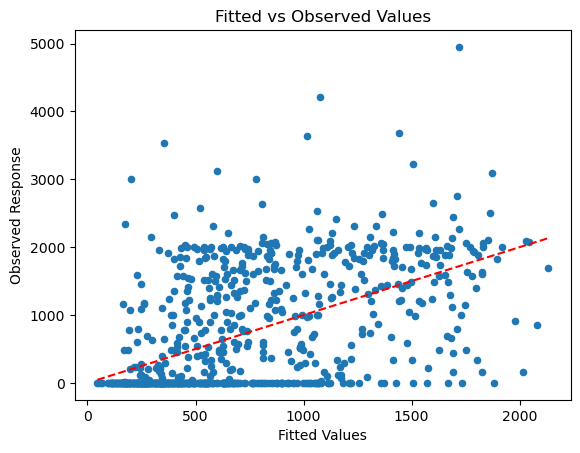

```python
import matplotlib.pyplot as plt
poireg_fitted_values = poiregmodel.fittedvalues
print(poireg_fitted_values)
plt.scatter(poireg_fitted_values, Y, alpha = 1, s = 20)
plt.plot([min(poireg_fitted_values), max(poireg_fitted_values)],[min(poireg_fitted_values), max(poireg_fitted_values)], color = 'red', linestyle = '--')
plt.xlabel('Fitted Values')
plt.ylabel('Observed Response')
plt.title('Fitted vs Observed Values')
plt.show()
```

Here are some observations from this plot.

1. The actual observed responses seem to vary between 0 and 5000 but the fitted values seem to be in a much more narrow region between 0 and a little over 2000.
2. There is quite a bit of spread around the $y = x$ line.
3. There exist observations where the actual response is 0 (or close to 0) but the fitted value is large
4. There exist observations where the actual response is somewhat large but the fitted value is small

The range of the actual responses and the fitted values can be found out as follows:

```python
print(f"Range of observed response: {[np.min(Y), np.max(Y)]}")
print(f"Range of fitted values: {[np.min(poireg_fitted_values), np.max(poireg_fitted_values)]}")
```

```
Range of observed response: [0, 4950]
Range of fitted values: [45.58196325662061, 2132.55829618613]
```

We can look at the data for the specific observations where there is a significant discrepancy between observed response and fitted values.

```python
#Observations where Y = 0 and fitted values are large
condition = (Y == 0) & (poireg_fitted_values > 1500)
df1 = mroz.loc[condition, ['hours', 'kidslt6', 'age', 'educ', 'huswage', 'exper', 'expersq']]
df2 = pd.DataFrame(poireg_fitted_values[condition], columns=["Fitted Values"])
combined = pd.concat([df1.reset_index(drop=True), df2.reset_index(drop=True)], axis=1)
print(combined)
print(poiregmodel.params)
#It is easy to see why the model gives large predictions (fitted_values) to these observations:
#these women have no kids and have high experience.
```

```
   hours  kidslt6  age  educ  huswage  exper  expersq  Fitted Values
0      0        0   38    12   5.6922     19      361    1733.075193
1      0        0   43    12   2.9510     25      625    1882.829625
2      0        0   49    12   1.9286     32     1024    1666.775722
3      0        0   55    16   2.6701     33     1089    1571.905555
4      0        0   41    12   3.7875     18      324    1504.698908
const      6.936480
kidslt6   -0.807524
age       -0.042680
educ       0.052831
huswage   -0.020714
exper      0.120372
expersq   -0.001829
dtype: float64
```

```python
#observations where the actual response is somewhat large but the fitted value is small
condition = (Y > 2000) & (poireg_fitted_values < 500)
df1 = mroz.loc[condition, ['hours', 'kidslt6', 'age', 'educ', 'huswage', 'exper', 'expersq']]
df2 = pd.DataFrame(poireg_fitted_values[condition], columns=["Fitted Values"])
combined = pd.concat([df1.reset_index(drop=True), df2.reset_index(drop=True)], axis=1)
print(combined)
print(poiregmodel.params)
#These women either have kids or have small exper and high age leading to small predictions (fitted values)
```

```
   hours  kidslt6  age  educ  huswage  exper  expersq  Fitted Values
0   2030        0   47    12   5.0870      6       36     452.821746
1   2480        1   39    10   8.6806     12      144     401.044507
2   2340        1   36    10   3.7129      1        1     174.582795
3   2149        0   45     8   4.5122      3        9     295.804050
4   3533        2   38    15   7.0000     17      289     352.452873
5   3000        0   51    14   8.8632      0        0     203.529784
const      6.936480
kidslt6   -0.807524
age       -0.042680
educ       0.052831
huswage   -0.020714
exper      0.120372
expersq   -0.001829
dtype: float64
```

### Posterior Predictive Distributions

Posterior predictive distributions offer a more principled way of model checking (compared to the basic method of plotting fitted values against observed responses). The fitted value is given by $\hat{\mu}_i := \exp \left(\hat{\beta}_0 + \hat{\beta}_1 x_{i1} + \dots + \hat{\beta}_m x_{im} \right)$. We always have some uncertainty associated with the coefficients $\hat{\beta}_0, \hat{\beta}_1, \dots, \hat{\beta}_m$ but this variability is not taken into account while calculating $\hat{\mu}_i$. In the last lecture, we saw that the variability can be captured by the posterior normal approximation: \begin{align*} \text{posterior} \approx N \left(\hat{\beta}, \left( - H\ell(\hat{\beta}) \right)^{-1}\right) = N \left(\hat{\beta}, \left(X^T M(\hat{\beta}) X \right)^{-1}\right) \end{align*} where $M(\beta)$ is the diagonal matrix with diagonal entries $\mu_1 = e^{x_1^T \beta}, \dots, \mu_n = e^{x_n^T \beta}$ and $\hat{\beta}$ is the MLE. Instead of the single fitted value $\hat{\mu}_i$, one can create a whole set of samples $\hat{\mu}_i^{(1)}, \dots, \hat{\mu}_i^{(N)}$ in the following way:

1. Generate $(\beta_0^{(j)}, \beta_1^{(j)}, \dots, \beta_m^{(j)})$ for $j = 1, \dots, N$ to be i.i.d from the above normal approximation to the posterior
2. Calculate $\hat{\mu}_i^{(j)} = \exp \left(\beta_0^{(j)} + \beta_1^{(j)} x_{i1} + \dots + \beta_m^{(j)} x_{im} \right)$ for each $j = 1, \dots, N$.

Instead of comparing $Y_i$ to the single fitted value $\hat{\mu}_i$, it makes sense to compare $Y_i$ to the whole set of values $\hat{\mu}_i^{(1)}, \dots, \hat{\mu}_i^{(N)}$. Note also that the model specifies that $Y_i$ is Poisson with mean $\mu_i$. Based on this, an even better comparison is to draw samples $Y_i^{(1)}, \dots, Y_i^{(N)}$ with $Y_i^{(j)} \sim \text{Poisson}(\hat{\mu}_i^{(j)})$. The distribution approximated by these samples $Y_i^{(1)}, \dots, Y_i^{(N)}$ is called the **posterior predictive distribution** for the $i^{th}$ observation (or corresponding to the explanatory variable values $x_{i1}, x_{i2}, \dots, x_{im})$. If the observed $Y_i$ is extreme compared to the histogram of $Y_i^{(1)}, \dots, Y_i^{(N)}$, then we can conclude that the model is not accurate for the $i^{th}$ observation.

The following code illustrates how $Y_i^{(1)}, \dots, Y_i^{(N)}$ can be obtained. The first step is to draw samples of $\beta$ from the posterior normal approximation.

```python
#Posterior Predictive Distributions:
#First obtain posterior samples:
cov_matrix = poiregmodel.cov_params() #this is the covariance matrix of the posterior normal approximation
print(cov_matrix)
#Manual computation of covariance matrix:
beta_hat = poiregmodel.params.values
log_muvec = np.dot(X, beta_hat)
muvec = np.exp(log_muvec)
M = np.diag(muvec)
Hessian = -X.T @ M @ X
Hessian_inv = np.linalg.inv(Hessian)
CovMat = -Hessian_inv
print(CovMat) #this coincides with poiregmodel.cov_params()
```

```
                const       kidslt6           age          educ       huswage  \
const    1.521851e-04 -1.094065e-05 -1.890439e-06 -4.802901e-06  1.794310e-07
kidslt6 -1.094065e-05  1.746699e-05  2.218647e-07 -1.421124e-07 -2.502671e-08
age     -1.890439e-06  2.218647e-07  4.501405e-08  1.130163e-08 -1.009965e-08
educ    -4.802901e-06 -1.421124e-07  1.130163e-08  4.008993e-07 -7.051506e-08
huswage  1.794310e-07 -2.502671e-08 -1.009965e-08 -7.051506e-08  1.441951e-07
exper   -2.275008e-06  2.447391e-07  9.708493e-09 -1.707776e-08  2.029966e-09
expersq  8.169060e-08 -6.410297e-09 -8.849655e-10  1.469846e-10  3.559604e-10

                exper       expersq
const   -2.275008e-06  8.169060e-08
kidslt6  2.447391e-07 -6.410297e-09
age      9.708493e-09 -8.849655e-10
educ    -1.707776e-08  1.469846e-10
huswage  2.029966e-09  3.559604e-10
exper    3.014745e-07 -8.400485e-09
expersq -8.400485e-09  2.661157e-10
[[ 1.52185070e-04 -1.09406532e-05 -1.89043951e-06 -4.80290153e-06
   1.79431046e-07 -2.27500844e-06  8.16905999e-08]
 [-1.09406532e-05  1.74669961e-05  2.21864692e-07 -1.42112412e-07
  -2.50267180e-08  2.44739159e-07 -6.41029810e-09]
 [-1.89043951e-06  2.21864692e-07  4.50140545e-08  1.13016300e-08
  -1.00996487e-08  9.70849310e-09 -8.84965506e-10]
 [-4.80290153e-06 -1.42112412e-07  1.13016300e-08  4.00899280e-07
  -7.05150573e-08 -1.70777559e-08  1.46984555e-10]
 [ 1.79431046e-07 -2.50267180e-08 -1.00996487e-08 -7.05150573e-08
   1.44195100e-07  2.02996543e-09  3.55960395e-10]
 [-2.27500844e-06  2.44739159e-07  9.70849310e-09 -1.70777559e-08
   2.02996543e-09  3.01474552e-07 -8.40048540e-09]
 [ 8.16905999e-08 -6.41029810e-09 -8.84965506e-10  1.46984555e-10
   3.55960395e-10 -8.40048540e-09  2.66115699e-10]]
```

```python
#Generating posterior beta samples:
n_samples = 1000
beta_samples = np.random.multivariate_normal(beta_hat, cov_matrix, n_samples)
print(beta_samples.shape)
print(beta_samples[:10])
```

```
(1000, 7)
[[ 6.92194536e+00 -8.03270772e-01 -4.24286435e-02  5.31064504e-02
  -2.08870726e-02  1.20842234e-01 -1.85190786e-03]
 [ 6.93385598e+00 -8.08114326e-01 -4.27041476e-02  5.33726205e-02
  -2.09114608e-02  1.20040017e-01 -1.81940021e-03]
 [ 6.92838759e+00 -8.04950338e-01 -4.24892209e-02  5.26605631e-02
  -2.02854229e-02  1.20542260e-01 -1.84123327e-03]
 [ 6.92248199e+00 -8.06713238e-01 -4.25091360e-02  5.32710713e-02
  -2.16870422e-02  1.21372727e-01 -1.85441246e-03]
 [ 6.95677092e+00 -8.10321674e-01 -4.31309003e-02  5.25048822e-02
  -2.07995923e-02  1.20545966e-01 -1.82656077e-03]
 [ 6.94115575e+00 -8.03133123e-01 -4.27210462e-02  5.25318769e-02
  -2.03102277e-02  1.20224158e-01 -1.82583563e-03]
 [ 6.92293173e+00 -8.08470247e-01 -4.26668913e-02  5.33084676e-02
  -2.05542698e-02  1.20943282e-01 -1.84161588e-03]
 [ 6.92499787e+00 -8.10092566e-01 -4.26821485e-02  5.41082290e-02
  -2.06054555e-02  1.19823778e-01 -1.81369128e-03]
 [ 6.94827919e+00 -8.07833747e-01 -4.28014843e-02  5.24328534e-02
  -2.06433929e-02  1.19881541e-01 -1.81066192e-03]
 [ 6.92673869e+00 -8.07883767e-01 -4.23639834e-02  5.29246453e-02
  -2.10721353e-02  1.20889993e-01 -1.85660273e-03]]
```